# NTC2-Übersensitivität — Per-Node-Regression

NTC2 gegen Mittel(NTC1,NTC3), kalibriert & roh — mit NTC1↔︎NTC3-Gegencheck

Author

Thom Laepple

Published

July 1, 2026

Die drei NTCs eines Snowmelt-Nodes sitzen je ~4 cm auseinander (NTC1–NTC2 und NTC2–NTC3 je 4 cm, **NTC1–NTC3 8 cm**) und sehen fast dasselbe Signal. Im Feld zeigt NTC2 einen etwas stärkeren Tagesgang. Wir quantifizieren das **pro Node** über die ganze geladene Zeitreihe mit einer linearen Regression

$$\text{NTC2} = a + b \cdot \tfrac{1}{2}(\text{NTC1}+\text{NTC3}),$$

```r
suppressMessages({library(dplyr); library(tidyr); library(ggplot2); library(patchwork)})

IMEI    <- "300434065508020"      # snowmelt NEWGRIP (ntc1/ntc2/testSB)
fields  <- c("ntc1", "ntc2", "testSB")
n_nodes <- 24L

# counts -> Temperatur (Standard-Beta, wie im Feld-Dekoder)
NTCcounts2temp <- function(c) {
  H <- (-c * 1e6) / (c - 33554432); r <- (H * 499000) / (499000 - H)
  1 / ((1 / 3380) * log(r / 10000) + 1 / 298.15) - 273.15
}

# kompakter Snowchain/Snowmelt-Reader (gleiche Logik wie decode_field.qmd)
bin_field_bytes <- function(f) if (f %in% c("ntc1","ntc2","testSB","pressure")) 3L else if (f=="gnd") 2L else stop()
read_bin <- function(path, fields, n_nodes) {
  raw <- readBin(path, "raw", file.info(path)$size); n <- length(raw); ints <- as.integer(raw)
  has_sep <- ints[5] == 0x7CL
  be <- function(b) sum(as.integer(b) * 256^rev(seq_along(b) - 1L))
  bs <- function(b) { v <- be(b); bt <- 8L*length(b); if (v >= 2^(bt-1L)) v - 2^bt else v }
  nf <- length(fields); w <- c(3L, rep(sapply(fields, bin_field_bytes), n_nodes), 2L)
  sg <- c(TRUE, rep(fields != "pressure", n_nodes), FALSE); nv <- length(w)
  d1 <- function(b, ww, s) { if (length(b) != ww) NA_real_ else if (s) bs(b) else be(b) }
  if (has_sep) {
    sp <- which(ints == 0x7CL); sp <- sp[sp >= 5L]; fs <- sp + 1L; fe <- c(sp[-1] - 1L, n)
    vl <- lapply(seq_len(min(length(sp), nv)), function(i) d1(raw[fs[i]:fe[i]], w[i], sg[i]))
  } else {
    p <- 5L; vl <- vector("list", nv)
    for (i in seq_len(nv)) { ww <- w[i]
      if (ww == 3L && p + 3L <= n && all(ints[p:(p+3L)] == c(1,0,0,0))) { vl[[i]] <- NA_real_; p <- p + 4L }
      else if (i == nv && p + ww - 1L > n && p <= n) { vl[[i]] <- be(raw[p:n]) * 256L^(ww - (n-p+1L)); p <- n + 1L }
      else { vl[[i]] <- d1(raw[p:(p+ww-1L)], ww, sg[i]); p <- p + ww } }
  }
  ndv <- vl[2:(1L + n_nodes*nf)]
  list(nodes = lapply(seq_len(n_nodes), function(i) setNames(ndv[((i-1L)*nf+1L):(i*nf)], fields)),
       time = be(raw[1:4]))
}
```

```r
# Alle Nachrichten dieses Kopfes, außer -2 (Kopf damals noch nicht aufgestellt).
files <- sort(Sys.glob(sprintf("../testdata/%s-*.bin", IMEI)))
files <- files[!grepl(sprintf("%s-2\\.bin$", IMEI), files)]
all   <- lapply(files, read_bin, fields = fields, n_nodes = n_nodes)
all   <- all[order(sapply(all, `[[`, "time"))]
times <- as.POSIXct(sapply(all, `[[`, "time"), origin = "1970-01-01", tz = "UTC")
n_msg <- length(all)

# Long: (node, msg, sensor) -> counts & temp
long <- do.call(rbind, lapply(seq_len(n_msg), function(m)
  do.call(rbind, lapply(seq_len(n_nodes), function(i)
    do.call(rbind, lapply(fields, function(f) {
      v <- all[[m]]$nodes[[i]][[f]]; v <- if (is.null(v)) NA_real_ else as.numeric(v)
      data.frame(node = i, msg = m, sensor = f, counts = v, temp = NTCcounts2temp(v))
    }))))))
long$sensor <- recode(long$sensor, ntc1 = "NTC1", ntc2 = "NTC2", testSB = "NTC3")

wide <- long |>
  pivot_wider(id_cols = c(node, msg), names_from = sensor, values_from = c(temp, counts))
```

Geladen: **10 Messungen**, 2026-06-29 18:16 – 2026-07-01 06:15 UTC (36 h).

```r
# Per-Node-Regression y ~ mean(x_cols). Gibt Steigung, Achsenabschnitt, SE, R²,
# Residual-SD (in y-Einheiten) zurück. y_col/x_cols beziehen sich auf `wide`.
fit_node <- function(d, y_col, x_cols) {
  y <- d[[y_col]]; x <- rowMeans(as.matrix(d[, x_cols, drop = FALSE]))
  ok <- is.finite(x) & is.finite(y); if (sum(ok) < 3L) return(NULL)
  m <- lm(y[ok] ~ x[ok]); cf <- summary(m)$coefficients
  data.frame(n = sum(ok), intercept = cf[1,1], slope = cf[2,1], slope_se = cf[2,2],
             r2 = summary(m)$r.squared, resid_sd = sigma(m))
}
regress <- function(y_col, x_cols, analysis, space)
  do.call(rbind, lapply(sort(unique(wide$node)), function(nd) {
    r <- fit_node(filter(wide, node == nd), y_col, x_cols)
    if (is.null(r)) NULL else cbind(node = nd, analysis = analysis, space = space, r) }))

reg <- rbind(
  regress("temp_NTC2",   c("temp_NTC1","temp_NTC3"),   "NTC2 ~ Mittel(NTC1,NTC3)", "kalibriert"),
  regress("counts_NTC2", c("counts_NTC1","counts_NTC3"),"NTC2 ~ Mittel(NTC1,NTC3)", "roh"),
  regress("temp_NTC1",   "temp_NTC3",                   "NTC1 ~ NTC3 (Gegencheck)", "kalibriert"),
  regress("counts_NTC1", "counts_NTC3",                 "NTC1 ~ NTC3 (Gegencheck)", "roh"))
reg$analysis <- factor(reg$analysis,
  levels = c("NTC2 ~ Mittel(NTC1,NTC3)", "NTC1 ~ NTC3 (Gegencheck)"))
```

# 1 — NTC2 gegen Mittel(NTC1, NTC3)

```r
summ <- reg |> group_by(analysis, space) |>
  summarise(Nodes = n(), `Steigung ⌀` = mean(slope), `Steigung sd` = sd(slope),
            `Nodes >1` = sum(slope > 1), `⌀ R²` = mean(r2),
            `⌀ Residual-SD` = mean(resid_sd),
            `p(Steigung=1)` = t.test(slope, mu = 1)$p.value, .groups = "drop")
knitr::kable(filter(summ, grepl("NTC2", analysis)), digits = c(0,0,0,4,4,0,4,4,3),
             caption = "NTC2 ~ Mittel(NTC1,NTC3): 24 Per-Node-Regressionen je Raum")
```

| analysis | space | Nodes | Steigung ⌀ | Steigung sd | Nodes >1 | ⌀ R² | ⌀ Residual-SD | p(Steigung=1) |
| --- | --- | --- | --- | --- | --- | --- | --- | --- |
| NTC2 ~ Mittel(NTC1,NTC3) | kalibriert | 23 | 1.0512 | 0.0360 | 21 | 0.9971 | 0.2618 | 0 |
| NTC2 ~ Mittel(NTC1,NTC3) | roh | 23 | 1.0523 | 0.0365 | 21 | 0.9976 | 14513.7003 | 0 |

[figure not shown]

```r
sp_pal <- c(kalibriert = "#c0392b", roh = "#2980b9")
d2 <- filter(reg, grepl("NTC2", analysis))
pA <- ggplot(d2, aes(node, slope, colour = space)) +
  geom_hline(yintercept = 1, colour = "grey40") +
  geom_errorbar(aes(ymin = slope-1.96*slope_se, ymax = slope+1.96*slope_se),
                width = 0, position = position_dodge(0.5), alpha = 0.6) +
  geom_point(size = 1.8, position = position_dodge(0.5)) +
  scale_colour_manual(values = sp_pal, name = NULL) +
  labs(title = "Per-Node-Steigung NTC2 ~ Mittel(NTC1,NTC3)",
       subtitle = sprintf("%d Punkte je Node | Linie = 1 (kein Mehr-Gang)", n_msg),
       x = "Node", y = "Steigung") +
  theme_bw(base_size = 12) +
  theme(legend.position = "inside", legend.position.inside = c(0.5, 0.12),
        legend.direction = "horizontal",
        legend.background = element_rect(fill = "white", colour = "grey80"))
pB <- ggplot(d2, aes(space, slope, colour = space, fill = space)) +
  geom_hline(yintercept = 1, colour = "grey40") +
  geom_boxplot(width = 0.4, alpha = 0.18, outlier.shape = NA) +
  geom_jitter(width = 0.08, size = 1.6, alpha = 0.7) +
  stat_summary(fun = mean, geom = "point", shape = 23, size = 3, fill = "white") +
  scale_colour_manual(values = sp_pal, guide = "none", aesthetics = c("colour","fill")) +
  labs(title = "Verteilung der 24 Steigungen", x = NULL, y = "Steigung") +
  theme_bw(base_size = 12)
pA + pB + plot_layout(widths = c(1.6, 1))
```

**NoteRobust und kalibrierungsunabhängig**

Die NTC2-Steigung liegt bei **1.052 ± 0.036** und ist in **21/23** Nodes > 1 (p ≈ 7e-07). **Kalibriert und roh sind praktisch identisch** (Korrelation über die Nodes: 0.992) — der ~5 %-Mehr-Gang steckt in den **counts**, nicht in der Kalibration.

# 2 — Gegencheck: NTC1 gegen NTC3 (8 cm Abstand)

Kein systematischer Gain-Unterschied zwischen den beiden Referenzsensoren erwartet (Steigung ≈ 1). Naiv würde man wegen des doppelten Abstands **mehr Streuung** erwarten — das prüfen wir gegen die tatsächlichen Residuen.

```r
knitr::kable(filter(summ, grepl("NTC1", analysis)), digits = c(0,0,0,4,4,0,4,4,3),
             caption = "NTC1 ~ NTC3: 24 Per-Node-Regressionen je Raum")
```

| analysis | space | Nodes | Steigung ⌀ | Steigung sd | Nodes >1 | ⌀ R² | ⌀ Residual-SD | p(Steigung=1) |
| --- | --- | --- | --- | --- | --- | --- | --- | --- |
| NTC2 ~ Mittel(NTC1,NTC3) | kalibriert | 23 | 1.0512 | 0.0360 | 21 | 0.9971 | 0.2618 | 0.000 |
| NTC2 ~ Mittel(NTC1,NTC3) | roh | 23 | 1.0523 | 0.0365 | 21 | 0.9976 | 14513.7003 | 0.000 |
| NTC1 ~ NTC3 (Gegencheck) | kalibriert | 23 | 1.0049 | 0.0352 | 10 | 0.9986 | 0.1600 | 0.511 |
| NTC1 ~ NTC3 (Gegencheck) | roh | 23 | 1.0030 | 0.0371 | 11 | 0.9989 | 8763.3141 | 0.702 |

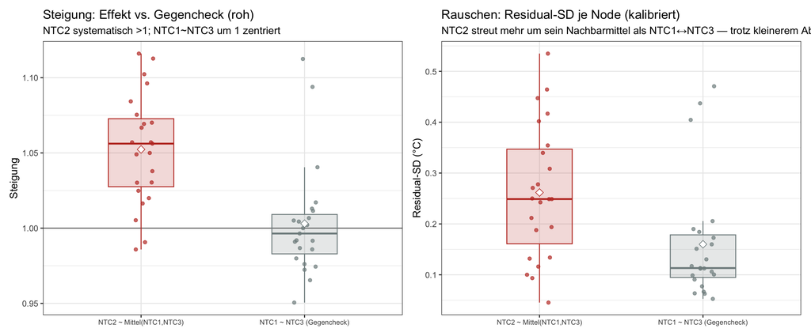

```r
# links: Steigungsverteilung beider Analysen (NTC2~Mittel vs NTC1~NTC3), roh
d_all <- filter(reg, space == "roh")
an_pal <- c(`NTC2 ~ Mittel(NTC1,NTC3)` = "#c0392b", `NTC1 ~ NTC3 (Gegencheck)` = "#7f8c8d")
q1 <- ggplot(d_all, aes(analysis, slope, colour = analysis, fill = analysis)) +
  geom_hline(yintercept = 1, colour = "grey40") +
  geom_boxplot(width = 0.4, alpha = 0.18, outlier.shape = NA) +
  geom_jitter(width = 0.08, size = 1.6, alpha = 0.7) +
  stat_summary(fun = mean, geom = "point", shape = 23, size = 3, fill = "white") +
  scale_colour_manual(values = an_pal, guide = "none", aesthetics = c("colour","fill")) +
  labs(title = "Steigung: Effekt vs. Gegencheck (roh)",
       subtitle = "NTC2 systematisch >1; NTC1~NTC3 um 1 zentriert", x = NULL, y = "Steigung") +
  theme_bw(base_size = 12) + theme(axis.text.x = element_text(size = 8))

# rechts: Rausch-Vergleich — Residual-SD je Node (kalibriert, °C)
d_rsd <- filter(reg, space == "kalibriert")
q2 <- ggplot(d_rsd, aes(analysis, resid_sd, colour = analysis, fill = analysis)) +
  geom_boxplot(width = 0.4, alpha = 0.18, outlier.shape = NA) +
  geom_jitter(width = 0.08, size = 1.6, alpha = 0.7) +
  stat_summary(fun = mean, geom = "point", shape = 23, size = 3, fill = "white") +
  scale_colour_manual(values = an_pal, guide = "none", aesthetics = c("colour","fill")) +
  labs(title = "Rauschen: Residual-SD je Node (kalibriert)",
       subtitle = "NTC2 streut mehr um sein Nachbarmittel als NTC1↔NTC3 — trotz kleinerem Abstand",
       x = NULL, y = "Residual-SD (°C)") +
  theme_bw(base_size = 12) + theme(axis.text.x = element_text(size = 8))
q1 + q2
```

```r
rsd_ntc2 <- mean(d_rsd$resid_sd[grepl("NTC2", d_rsd$analysis)])
rsd_cc   <- mean(d_rsd$resid_sd[grepl("NTC1", d_rsd$analysis)])
r2_ntc2  <- mean(d_rsd$r2[grepl("NTC2", d_rsd$analysis)])
r2_cc    <- mean(d_rsd$r2[grepl("NTC1", d_rsd$analysis)])
s_cc     <- d_all$slope[grepl("NTC1", d_all$analysis)]
```

# 3 — Sieht der Zusammenhang linear aus?

Beispiel-Regressionen einzelner Nodes (NTC2 gegen das Nachbarmittel, kalibriert) — zum Prüfen, ob die Punktwolke ungefähr auf einer Geraden liegt:

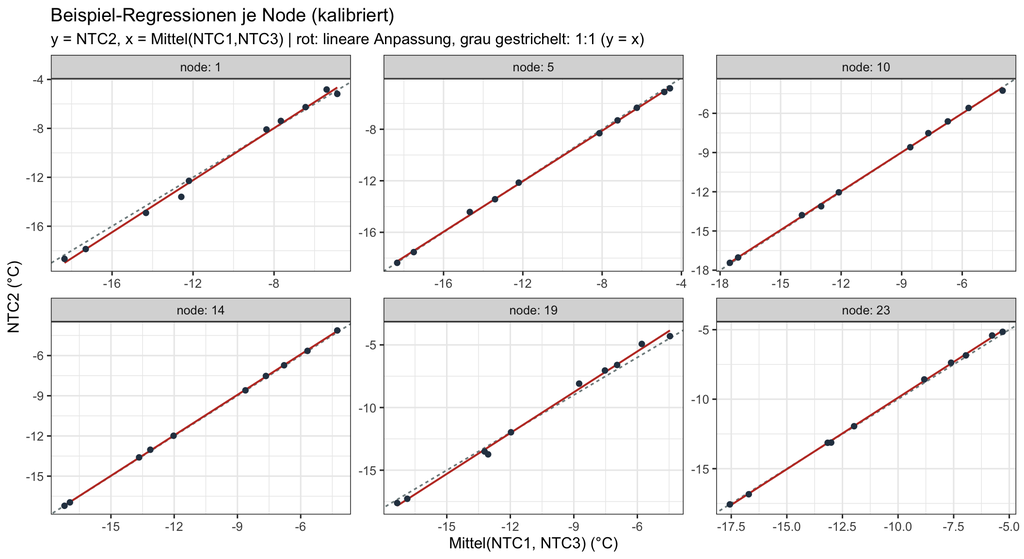

```r
ex_df <- wide |> mutate(xmean = (temp_NTC1 + temp_NTC3) / 2, y = temp_NTC2) |>
  filter(is.finite(xmean), is.finite(y))
un <- sort(unique(ex_df$node)); ex_nodes <- un[round(seq(1, length(un), length.out = 6))]
ggplot(filter(ex_df, node %in% ex_nodes), aes(xmean, y)) +
  geom_abline(slope = 1, intercept = 0, colour = "#7f8c8d", linetype = "22", linewidth = 0.6) +
  geom_smooth(method = "lm", se = FALSE, colour = "#c0392b", linewidth = 0.7) +
  geom_point(size = 1.7, colour = "#2c3e50") +
  facet_wrap(~ node, labeller = label_both, scales = "free") +
  labs(title = "Beispiel-Regressionen je Node (kalibriert)",
       subtitle = "y = NTC2, x = Mittel(NTC1,NTC3) | rot: lineare Anpassung, grau gestrichelt: 1:1 (y = x)",
       x = "Mittel(NTC1, NTC3) (°C)", y = "NTC2 (°C)") +
  theme_bw(base_size = 12)
```

Gemittelter Zusammenhang: bei jedem Node ziehen wir das **Node-Mittel** von x und y ab (entfernt den Offset) und poolen alle Nodes. So überlagern sich alle Tagesgänge und der gemeinsame NTC2-vs-Nachbar-Zusammenhang wird als eine Punktwolke sichtbar — mit linearer Anpassung (rot) und einer loess-Kurve (blau) als Krümmungstest.

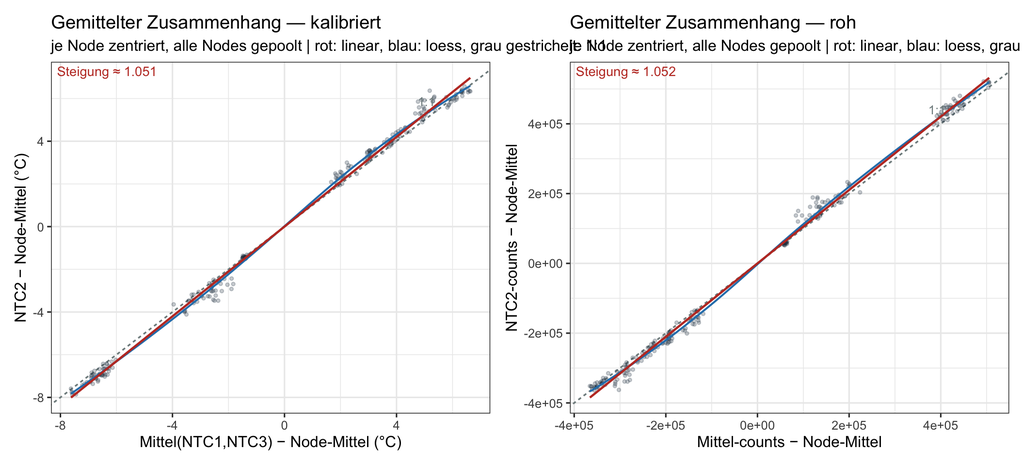

```r
center_pool <- function(x1, x2, yv) wide |>
  mutate(xmean = (.data[[x1]] + .data[[x2]]) / 2, y = .data[[yv]]) |>
  filter(is.finite(xmean), is.finite(y)) |>
  group_by(node) |> mutate(xc = xmean - mean(xmean), yc = y - mean(y)) |> ungroup()
poolT <- center_pool("temp_NTC1",  "temp_NTC3",  "temp_NTC2")
poolC <- center_pool("counts_NTC1","counts_NTC3","counts_NTC2")
slT <- coef(lm(yc ~ xc + 0, poolT)); slC <- coef(lm(yc ~ xc + 0, poolC))

mkpool <- function(d, sl, xl, yl, ttl) { mx <- max(d$xc, na.rm = TRUE)
  ggplot(d, aes(xc, yc)) +
  geom_abline(slope = 1, intercept = 0, colour = "#7f8c8d", linetype = "22", linewidth = 0.6) +
  geom_point(alpha = 0.25, size = 1, colour = "#2c3e50") +
  geom_smooth(method = "loess", se = FALSE, colour = "#2980b9", linewidth = 0.7) +
  geom_smooth(method = "lm", formula = y ~ x + 0, se = FALSE, colour = "#c0392b", linewidth = 0.8) +
  annotate("text", x = 0.82 * mx, y = 0.82 * mx, label = "1:1", colour = "#7f8c8d",
           size = 3.4, vjust = -0.5, hjust = 1.1) +
  annotate("text", x = -Inf, y = Inf, hjust = -0.06, vjust = 1.5, size = 3.6,
           colour = "#c0392b", label = sprintf("Steigung ≈ %.3f", sl)) +
  labs(title = ttl,
       subtitle = "je Node zentriert, alle Nodes gepoolt | rot: linear, blau: loess, grau gestrichelt: 1:1",
       x = xl, y = yl) +
  theme_bw(base_size = 12) }

mkpool(poolT, slT, "Mittel(NTC1,NTC3) − Node-Mittel (°C)", "NTC2 − Node-Mittel (°C)",
       "Gemittelter Zusammenhang — kalibriert") +
mkpool(poolC, slC, "Mittel-counts − Node-Mittel", "NTC2-counts − Node-Mittel",
       "Gemittelter Zusammenhang — roh")
```

Lineare Anpassung (rot) und loess (blau) liegen über den ganzen ~14 °C-Bereich eng beieinander (Restkrümmung ≲ 0.3 °C, nahe dem Sägezahn-Übergang bei ~−12 °C) → der Zusammenhang ist **in guter Näherung linear**; eine einzelne Steigung (≈ 1.051) beschreibt ihn zutreffend. Die gepoolte Steigung stimmt exakt mit dem Mittel der 23 Einzelregressionen (1.051) überein.

# 4 — Selbsterwärmung? Ist NTC2 immer wärmer?

Bei Selbsterwärmung würde NTC2 die Messleistung als Wärme abführen und **immer** wärmer lesen als die Nachbarn — der Effekt kann nur Wärme *hinzufügen*, also $d = \text{NTC2} - \tfrac{1}{2}(\text{NTC1}+\text{NTC3}) \ge 0$ über den ganzen Bereich (und stärker bei Wärme, weil dann mehr Leistung fließt). Ein reiner *Gain* dagegen macht NTC2 kälter-wenn-kalt und wärmer-wenn-warm, mit Vorzeichenwechsel in der Mitte. Wir prüfen $d$ gegen die Temperatur (kalibriert).

```r
sh <- wide |> mutate(xmean = (temp_NTC1 + temp_NTC3) / 2, d = temp_NTC2 - xmean) |>
  filter(is.finite(xmean), is.finite(d))
terc <- sh |>
  mutate(bin = cut(xmean, quantile(xmean, c(0,.33,.66,1)), include.lowest = TRUE,
                   labels = c("kalt","mittel","warm"))) |>
  group_by(Bereich = bin) |>
  summarise(`⌀ Temp (°C)` = mean(xmean), `⌀ d (°C)` = mean(d),
            `Anteil d>0 (%)` = 100*mean(d > 0), n = n(), .groups = "drop")
per_node_sh <- sh |> group_by(node) |>
  summarise(always_warm = all(d > 0),
            cross = { m <- lm(temp_NTC2 ~ xmean); -coef(m)[1]/(coef(m)[2]-1) },
            .groups = "drop")
cx <- { m <- lm(d ~ xmean, sh); -coef(m)[1]/coef(m)[2] }   # gepoolter Nulldurchgang
knitr::kable(terc, digits = c(0,1,3,0,0),
  caption = "d = NTC2 − Mittel(NTC1,NTC3) nach Temperatur-Terzil (kalibriert)")
```

d = NTC2 − Mittel(NTC1,NTC3) nach Temperatur-Terzil (kalibriert)

| Bereich | ⌀ Temp (°C) | ⌀ d (°C) | Anteil d>0 (%) | n |
| --- | --- | --- | --- | --- |
| kalt | -15.9 | -0.239 | 14 | 76 |
| mittel | -10.4 | 0.052 | 63 | 76 |
| warm | -5.8 | 0.262 | 78 | 78 |

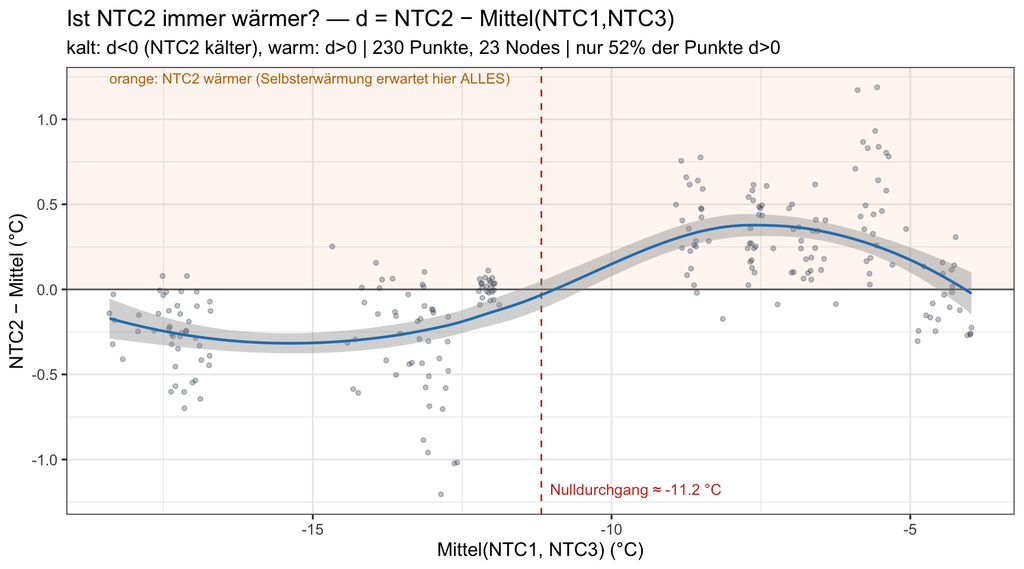

```r
ggplot(sh, aes(xmean, d)) +
  annotate("rect", xmin = -Inf, xmax = Inf, ymin = 0, ymax = Inf, fill = "#e67e22", alpha = 0.07) +
  geom_hline(yintercept = 0, colour = "grey40") +
  geom_vline(xintercept = cx, colour = "#c0392b", linetype = "dashed") +
  geom_point(alpha = 0.3, size = 1.1, colour = "#2c3e50") +
  geom_smooth(method = "loess", se = TRUE, colour = "#2980b9", linewidth = 0.8) +
  annotate("text", x = cx, y = min(sh$d), label = sprintf("Nulldurchgang ≈ %.1f °C", cx),
           colour = "#c0392b", hjust = -0.05, vjust = 0, size = 3.4) +
  annotate("text", x = min(sh$xmean), y = Inf, hjust = 0, vjust = 1.6, size = 3.2,
           colour = "#b9770e", label = "orange: NTC2 wärmer (Selbsterwärmung erwartet hier ALLES)") +
  labs(title = "Ist NTC2 immer wärmer? — d = NTC2 − Mittel(NTC1,NTC3)",
       subtitle = sprintf("kalt: d<0 (NTC2 kälter), warm: d>0 | %d Punkte, %d Nodes | nur %.0f%% der Punkte d>0",
                          nrow(sh), length(unique(sh$node)), 100*mean(sh$d > 0)),
       x = "Mittel(NTC1, NTC3) (°C)", y = "NTC2 − Mittel (°C)") +
  theme_bw(base_size = 12)
```

**ImportantNein — NTC2 ist nicht immer wärmer → gegen Selbsterwärmung**

- **0 von 23 Nodes** haben durchgehend d > 0. Insgesamt sind nur **52 %** der Punkte positiv (⌀ d = +0.03 °C — nahe null).
- **Kälter wenn kalt** (d = -0.24 °C bei -16 °C), **wärmer wenn warm** (+0.26 °C bei -6 °C). Nulldurchgang bei **-11.2 °C**, mitten im Messbereich.
- Das ist ein **symmetrischer Gain** (~5 % größere Amplitude um einen Arbeitspunkt), kein einseitiger Offset. **Selbsterwärmung kann nur Wärme hinzufügen** (d ≥ 0 überall) und NTC2 am kalten Ende nicht *kälter* machen — sie ist damit ausgeschlossen als Hauptursache. Signatur eher: Skalen-/Gain-Unterschied auf Kanal 2 (z. B. ADC-Referenz / Anregung / Vorwiderstand).

## Warum wächst die Abweichung mit der Temperatur? (Rechnung)

Nicht weil es „bei Wärme mehr heizt”, sondern weil es ein **multiplikativer Gain** ist. NTC2 verstärkt das gemeinsame Signal um einen Faktor $g$ — in counts wie in Temperatur gleich (1.052 bzw. 1.050). Mit $\text{NTC2} = a + g\cdot\bar T$ folgt für die Abweichung unmittelbar

$$d = \text{NTC2} - \bar T = (g-1)\,(\,\bar T - T_0\,), \qquad T_0 = \frac{-a}{\,g-1\,},$$

also $d$ = 5 % des **Abstands vom Arbeitspunkt** $T_0 \approx$ -11.2 °C. Das reproduziert die Beobachtung punktgenau:

```r
mg <- lm(temp_NTC2 ~ xmean, sh); g <- coef(mg)[2]; T0 <- -coef(mg)[1]/(g-1)
terc |> transmute(Bereich,
                  `T (°C)`            = round(`⌀ Temp (°C)`, 1),
                  `d = (g−1)(T−T₀)`   = round((g-1)*(`⌀ Temp (°C)` - T0), 3),
                  `d beobachtet (°C)` = round(`⌀ d (°C)`, 3)) |>
  knitr::kable(caption = sprintf(
    "Vorhersage aus dem reinen Gain (g=%.3f, T₀=%.1f °C) vs. Beobachtung", g, T0))
```

Vorhersage aus dem reinen Gain (g=1.050, T₀=-11.2 °C) vs. Beobachtung

| Bereich | T (°C) | d = (g−1)(T−T₀) | d beobachtet (°C) |
| --- | --- | --- | --- |
| kalt | -15.9 | -0.238 | -0.239 |
| mittel | -10.4 | 0.040 | 0.052 |
| warm | -5.8 | 0.271 | 0.262 |

```r
q <- summary(lm(d ~ xmean + I(xmean^2), sh))$coefficients[3, 4]
```

# Fazit

Über 10 Messungen und 23 Nodes ist der NTC2-Mehr-Gang **~5 %, robust** (21/23 Nodes > 1, R² ≈ 0.998) und **kalibrierungsneutral** (kalibriert ≈ roh). Der Gegencheck NTC1↔︎NTC3 zeigt Steigung ≈ 1 (kein Gain zwischen den Referenzsensoren) und — entgegen der Distanz-Erwartung — sogar **geringere** Streuung als NTC2. Der NTC2-Effekt ist also ein echter Kanal-/Sensor-Effekt (höherer Gain **und** mehr Streuung), kein Artefakt von Abstand, Rauschen oder Kalibration.

```r
reg |> transmute(node, analysis, space, slope = round(slope, 4),
                 `pm95` = round(1.96*slope_se, 4), intercept = round(intercept, 3),
                 r2 = round(r2, 5), resid_sd = round(resid_sd, 4)) |>
  arrange(analysis, space, node) |>
  write.csv("data/ntc2_pernode_regression.csv", row.names = FALSE)
```